# Cvičení L2

Jan Netík

#### 1.1.1

$var(T) = 1$

$var(e) = 1$
$$rel(X)=\frac{var(T)}{var(T+e)} = \frac{1}{1+1} = 0,5$$

#### 1.1.2

Variance chybového členu je $10\times$ menší, reliabilita bude tudíž $1,\overline{81}\times$ **větší**.

#### 1.1.3

Pakliže původní $var(T) = 1$ a $var(e) = 1$, zdvojnásobení $var(T)$ povede k $1,\overline{3}\times$ **větší** reliabilitě.

#### 1.2.1

```r
set.seed(1)

true_score <- rnorm(100, 5, 1)
error_term <- rnorm(100, 0, 1)
```

Náhled:

```r
head(true_score)
```

```
## [1] 4.373546 5.183643 4.164371 6.595281 5.329508 4.179532
```

```r
head(error_term)
```

```
## [1] -0.62036668  0.04211587 -0.91092165  0.15802877 -0.65458464  1.76728727
```

#### 1.2.2

Vypočteme pozorované skóre a reliabilitu jako podíl variance pravého a pozorovaného skóru i jakožto koeficient determinace.

```r
observed_score <- true_score + error_term
```

```r
var(true_score)/(var(observed_score))
```

```
## [1] 0.4683443
```

```r
cor(true_score, observed_score)^2
```

```
## [1] 0.4673515
```

Reliabilita vypočtená na základě náhodných výběrů neodpovídá *přesně* teoretické reliabilitě vypočtené ze známých variancí. S rostoucím počtem výběrů odhad konverguje k teoretické hodnotě (viz následující bod).

#### 1.2.3

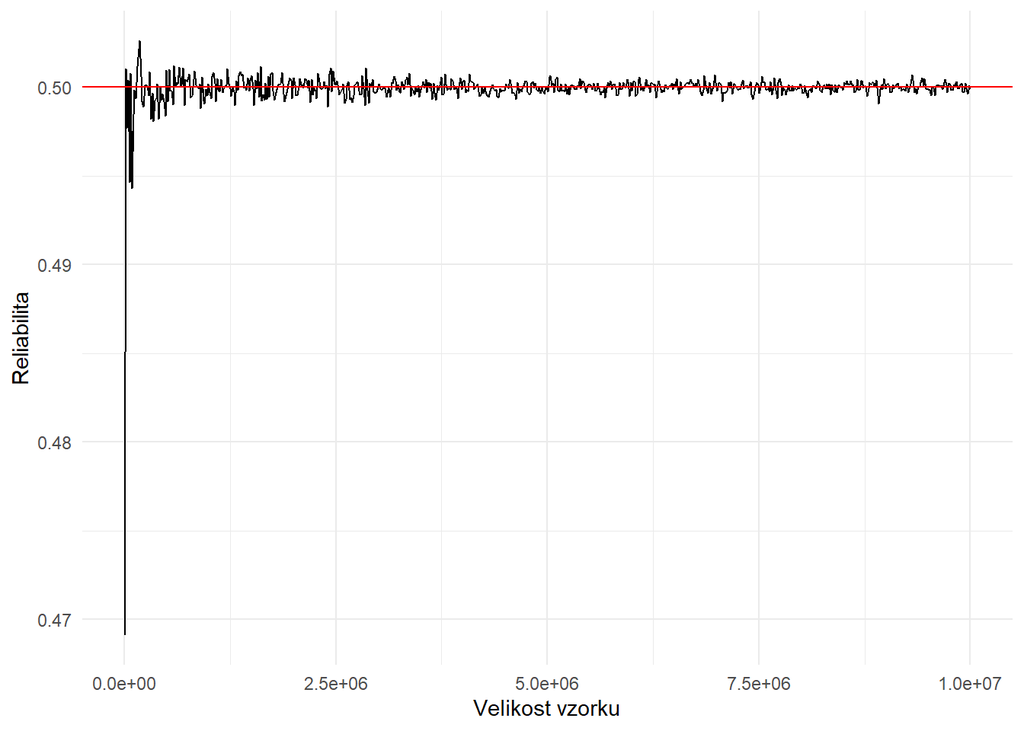

```r
n <- seq(100, 10000000, length.out = 666)
reliability <- numeric()

for (i in 1:length(n)) {
  true_score <- rnorm(n[i], 5, 1)
  error_term <- rnorm(n[i], 0, 1)

  reliability[i] <- var(true_score)/(var(true_score+error_term))
}

sh <- tibble(n = n, reliability = reliability)
ggplot(sh, aes(n, reliability)) + geom_line() + labs(x = "Velikost vzorku", y = "Reliabilita") + geom_hline(yintercept = .5, color = "red") +  theme_minimal()
```

Je patrné, že hodnoty vypočtené na základě velkých vzorků jsou blíže teoretické reliabilitě (vyznačená červenou přímkou).

#### 1.3.1

$n_{original\ items} = 5$

$n_{present\ items} = 10$

$rel(X) = 0,7$

$m = \frac{n_{present\ items}}{n_{original\ items}} = \frac{10}{5} = 2$

#### 1.3.2

$rel(X) = 0,7$

$rel(X') = 0,9$

$n_{original\ items} = 5$

$n_{items} = ?$

$$rel(X') = \frac{m \cdot rel(X)}{1+(m-1) rel(X)}$$
$$rel(X')[1+(m-1) rel(X)] = m \cdot rel(X)$$
$$rel(X') + rel(X')(m-1)rel(X) = m \cdot rel(X)$$
$$rel(X') + m\cdot rel(X')rel(X)- rel(X')rel(X) = m \cdot rel(X)$$
$$rel(X')-rel(X')rel(X)=m\cdot rel(X) - m \cdot rel(X')rel(X)$$
$$rel(X')-rel(X')rel(X)= m[rel(X) - rel(X')rel(X)]$$
$$\frac{rel(X')-rel(X')rel(X)}{rel(X) - rel(X')rel(X)}= m$$
$$\frac{rel(X')[1-rel(X)]}{rel(X)[1-rel(X')]}= m$$

$$m = \frac{0,9(1-0,7)}{0,7(1-0,9)} = \frac{0,9\cdot 0,3}{0,7\cdot 0,1} = \frac{0,27}{0,07} \approx 3,86$$

#### 1.3.3

```r
m = SBlength(.9, .7)
m*5
```

```
## [1] 19.28571
```

Výsledek je blízko našemu výpočtu výše, při kterém jsme *zaokrouhlovali.*

#### 2.1.1

$r_{test-retest} \approx 0,77$

#### 2.1.2

| Metoda | Test | Retest |
| --- | --- | --- |
| First-last | 0.65 | 0.62 |
| Odd-even | 0.73 | 0.67 |
| Random | 0.78 | 0.70 |
| Average (10,000) | 0.73 | 0.68 |
| Average (all) | 0.73 | 0.68 |
| Revelle’s $\beta$ | 0.36 | 0.28 |

#### 2.1.3

$\alpha_{test} = 0,71;\ \ \ \ \ \ \ \ 95\%\ CI = [0,57; 0,82]$

$\alpha_{retest} = 0,57;\ \ \ \ \ \ \ \ 95\%\ CI = [0,37; 0,73]$

#### 3.1.1

- nepřesný odhad měřeného atributu
- široké konfidenční intervaly
- oslabení maximální možné hodnoty korelací mezi kritériem a psychometrickou metodou
- potřeba komenzace nedostatečné reliability větším výběrovým souborem pro získání dostatečné statistické síly

#### 3.1.2

- navýšení počtu položek (viz výše)
- odebrání špatných položek (měřících jiný konstrukt, nejasně zadaných apod.)
- stanovení přesných krit=rií hodnocení (v případě více hodnotitelů)
- navýšení počtu hodnotitelů

#### 3.1.3

Většinou se Cronbachovo alfa považuje za měřítko „vnitřní konzistence“ testu. Jde o reliabilitu složeného měření.

#### 3.1.4

Porušení podmínek Cronbachovy alfy:

- více latentních konstruktů
- korelované chyby
- více zdrojů chyb
- nenormální rozdělení

Alternativní řešení:

- logistická alfa v případě binárních položek
- teorie zobecnitelnosti
- McDonaldovo omega
- strukturní modelování

#### 4

No konci prezentace, v části „Vocabulary“ je uvedeno „Generalizability theory, Facet, Dependability, Generalizability“, ale témata jsem našel jen v článku. Jinak děkuji za perfektní prezentaci i cvičení!